# Stretch02 (Assignment07)

Author

Huixin Cai & Ming Zhou

## 1 Set up

**a. Data** Our goal is to use individuals’ social and economic characteristics (e.g. gender, age, education, race, social assistance, SNAP benefits, etc.) to predict individuals’ employment status. The employment status - A_EXPLP is our target variable, which is a categorical variable with 3 values (0 for not in universe,1 for employed, 2 for unemployed). The data is Annual Social and Economic (ASEC) Supplement. It provides the usual monthly labor force data, but in addition, provides supplemental data on work experience, income, non-cash benefits, and migration. Comprehensive work experience information is given on the employment status, occupation, and industry of persons 15 years old and above.

```r
# load data
library(tidyverse)
library(lubridate)
library(dplyr)
data <- read_csv("Data/pppub22.csv")

# manually select predictor variables
data1 <- data %>%
  select(A_EXPLF,MIG_REG, SPM_NUMKIDS, SPM_ACTC, SPM_BBSUBVAL,
         SPM_FAMTYPE, SPM_CAPHOUSESUB, SPM_CAPWKCCXPNS, SPM_CHILDCAREXPNS,
         A_HGA, SPM_CHILDSUPPD, SPM_EITC, A_MARITL, HEA, SPM_FEDTAX, SPM_GEOADJ,
         SPM_ENGVAL, PRDTRACE, PHIP_VAL, MCAID, NOW_MCAID, NOW_DEPNONM,
         NOW_MRKUN, MRKUN, NOW_MRK, MRK, NOW_DIR, OWNDIR, COV, COV_CYR, AGI,
         EIT_CRED, CHSP_VAL, CSP_VAL, PAW_VAL, RINT_SC2, RINT_VAL1, PTOTVAL, DIS_HP,
         DIS_CS, DIS_CS, DIS_YN, DIV_YN, DSAB_VAL, PEARNVAL, EARNER, LKWEEKS, LOSEWKS)

# convert outcome variable to factor
data1$A_EXPLF <- as.factor(data1$A_EXPLF)
```

**b. Split the data**

```r
library(tidymodels)
set.seed(20221111)
split <- initial_split(data = data1, prop = 0.8)
data_training <- training(x = split)
data_testing <- testing(x = split)
```

**c. Exploratory data analysis**

```r
library(dplyr)
library(ggplot2)
# Take a overview of the data
glimpse(data_training)
```

```
Rows: 122,185
Columns: 47
$ A_EXPLF           <fct> 0, 0, 0, 0, 1, 0, 1, 0, 1, 0, 1, 1, 0, 1, 1, 0, 0, 0…
$ MIG_REG           <dbl> 1, 4, 2, 4, 1, 3, 4, 3, 4, 1, 3, 2, 3, 1, 3, 4, 4, 1…
$ SPM_NUMKIDS       <dbl> 0, 3, 6, 2, 2, 0, 3, 2, 1, 1, 0, 1, 0, 3, 1, 2, 1, 0…
$ SPM_ACTC          <dbl> 0, 9000, 18600, 4250, 6000, 0, 4500, 4600, 2500, 300…
$ SPM_BBSUBVAL      <dbl> 0, 50, 0, 0, 0, 0, 0, 0, 0, 0, 0, 0, 0, 0, 0, 0, 0, …
$ SPM_FAMTYPE       <dbl> 2, 3, 2, 1, 1, 5, 1, 3, 1, 1, 5, 1, 5, 1, 3, 1, 1, 5…
$ SPM_CAPHOUSESUB   <dbl> 0, 0, 0, 0, 0, 0, 0, 0, 0, 0, 0, 0, 0, 0, 0, 0, 0, 0…
$ SPM_CAPWKCCXPNS   <dbl> 1408, 2778, 6242, 7116, 1979, 0, 38540, 3958, 3958, …
$ SPM_CHILDCAREXPNS <dbl> 0, 0, 0, 3500, 0, 0, 35000, 0, 0, 5800, 0, 0, 0, 0, …
$ A_HGA             <dbl> 36, 39, 0, 0, 43, 37, 46, 0, 43, 0, 43, 35, 32, 43, …
$ SPM_CHILDSUPPD    <dbl> 0, 0, 0, 0, 0, 0, 0, 0, 0, 0, 0, 0, 0, 0, 0, 0, 0, 0…
$ SPM_EITC          <dbl> 1683, 4015, 306, 0, 0, 0, 0, 0, 0, 0, 0, 0, 0, 0, 34…
$ A_MARITL          <dbl> 7, 7, 7, 7, 1, 5, 1, 7, 1, 7, 7, 7, 4, 1, 6, 7, 7, 4…
```

[output cut: 34 more lines]

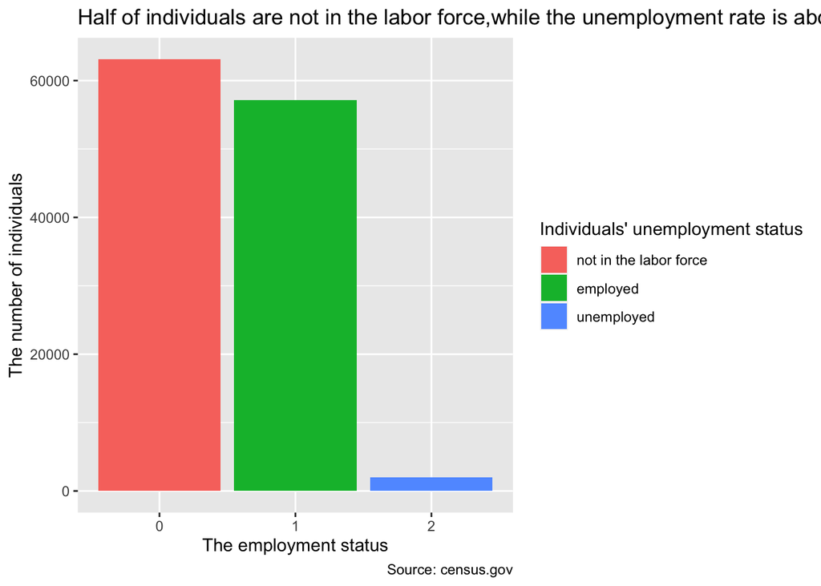

```r
# The Distribution of the dependent variable (individuals' employment status)
data_training %>%
  filter(complete.cases(.)) %>%
  ggplot(aes(x=A_EXPLF)) +
  geom_bar(aes(fill=factor(A_EXPLF))) +
  scale_fill_discrete(labels=c('not in the labor force',
                               'employed',
                               'unemployed')) +
  labs(y = "The number of individuals",
       x = "The employment status",
       title = paste0("Half of individuals are not in the labor force,",
       "while the unemployment rate is about 3.3%"),
       fill = "Individuals' unemployment status",
       caption = "Source: census.gov")
```

```r
# The Distribution of the regressors and controlled variables
summary(data_training)
```

```
 A_EXPLF      MIG_REG       SPM_NUMKIDS        SPM_ACTC      SPM_BBSUBVAL
 0:63110   Min.   :0.000   Min.   : 0.000   Min.   :    0   Min.   :  0.000
 1:57109   1st Qu.:2.000   1st Qu.: 0.000   1st Qu.:    0   1st Qu.:  0.000
 2: 1966   Median :3.000   Median : 1.000   Median : 2000   Median :  0.000
           Mean   :2.783   Mean   : 1.152   Mean   : 3337   Mean   :  7.051
           3rd Qu.:4.000   3rd Qu.: 2.000   3rd Qu.: 6000   3rd Qu.:  0.000
           Max.   :5.000   Max.   :12.000   Max.   :37800   Max.   :600.000
  SPM_FAMTYPE    SPM_CAPHOUSESUB   SPM_CAPWKCCXPNS  SPM_CHILDCAREXPNS
 Min.   :1.000   Min.   :    0.0   Min.   :     0   Min.   :     0.0
 1st Qu.:1.000   1st Qu.:    0.0   1st Qu.:  1979   1st Qu.:     0.0
 Median :1.000   Median :    0.0   Median :  2360   Median :     0.0
 Mean   :1.994   Mean   :  212.6   Mean   :  3407   Mean   :   872.2
 3rd Qu.:3.000   3rd Qu.:    0.0   3rd Qu.:  3958   3rd Qu.:     0.0
 Max.   :5.000   Max.   :30900.0   Max.   :184979   Max.   :648960.0
     A_HGA       SPM_CHILDSUPPD       SPM_EITC          A_MARITL
 Min.   : 0.00   Min.   :    0.0   Min.   :    0.0   Min.   :1.000
 1st Qu.:35.00   1st Qu.:    0.0   1st Qu.:    0.0   1st Qu.:1.000
 Median :39.00   Median :    0.0   Median :    0.0   Median :5.000
 Mean   :32.03   Mean   :  143.1   Mean   :  594.5   Mean   :4.296
 3rd Qu.:43.00   3rd Qu.:    0.0   3rd Qu.:    0.0   3rd Qu.:7.000
 Max.   :46.00   Max.   :99000.0   Max.   :12607.0   Max.   :7.000
      HEA          SPM_FEDTAX       SPM_GEOADJ       SPM_ENGVAL
 Min.   :1.000   Min.   :-54591   Min.   :0.8096   Min.   :    0.00
 1st Qu.:1.000   1st Qu.: -6293   1st Qu.:0.9116   1st Qu.:    0.00
 Median :2.000   Median :  -991   Median :0.9816   Median :    0.00
 Mean   :2.194   Mean   :  6803   Mean   :1.0149   Mean   :   21.89
 3rd Qu.:3.000   3rd Qu.:  9147   3rd Qu.:1.0784   3rd Qu.:    0.00
 Max.   :5.000   Max.   :938324   Max.   :1.5694   Max.   :10000.00
    PRDTRACE         PHIP_VAL            MCAID       NOW_MCAID
 Min.   : 1.000   Min.   :     0.0   Min.   :0.0   Min.   :1.000
 1st Qu.: 1.000   1st Qu.:     0.0   1st Qu.:2.0   1st Qu.:2.000
 Median : 1.000   Median :     0.0   Median :2.0   Median :2.000
 Mean   : 1.603   Mean   :   931.8   Mean   :1.8   Mean   :1.805
 3rd Qu.: 1.000   3rd Qu.:   600.0   3rd Qu.:2.0   3rd Qu.:2.000
 Max.   :26.000   Max.   :160000.0   Max.   :2.0   Max.   :2.000
  NOW_DEPNONM       NOW_MRKUN        MRKUN          NOW_MRK
 Min.   :0.0000   Min.   :1.00   Min.   :0.000   Min.   :1.000
 1st Qu.:0.0000   1st Qu.:2.00   1st Qu.:2.000   1st Qu.:2.000
 Median :0.0000   Median :2.00   Median :2.000   Median :2.000
 Mean   :0.1116   Mean   :1.99   Mean   :1.986   Mean   :1.968
```

[output cut: 29 more lines]

```
 Max.   :1906003   Max.   :2.000   Max.   :2.000   Max.   :2.000
     DIV_YN         DSAB_VAL           PEARNVAL           EARNER
 Min.   :0.000   Min.   :     0.0   Min.   :  -9999   Min.   :0.000
 1st Qu.:1.000   1st Qu.:     0.0   1st Qu.:      0   1st Qu.:1.000
 Median :2.000   Median :     0.0   Median :      0   Median :1.000
 Mean   :1.479   Mean   :    98.4   Mean   :  30812   Mean   :1.092
 3rd Qu.:2.000   3rd Qu.:     0.0   3rd Qu.:  45000   3rd Qu.:2.000
 Max.   :2.000   Max.   :100000.0   Max.   :1714999   Max.   :2.000
    LKWEEKS           LOSEWKS
 Min.   : 0.0000   Min.   :0.00000
 1st Qu.: 0.0000   1st Qu.:0.00000
 Median : 0.0000   Median :0.00000
 Mean   : 0.6826   Mean   :0.02157
 3rd Qu.: 0.0000   3rd Qu.:0.00000
 Max.   :51.0000   Max.   :2.00000
```

**d. Explicitly pick an error metric** False negative has higher cost (the person is unemployed but the model predicts them to be employed, in that way the budget for unemployment compensation provided by the government would not be enough), while false positive would lead to excessive budget, which does less harm.

## 2 Come up with Models & 3 Estimation

```r
library(tidymodels)
#Build a recipe
data_rec <- recipe(A_EXPLF~ ., data = data_training) %>%
  # center and scale all predictors
  step_normalize(all_predictors()) %>%
  step_corr(all_predictors())
```

**KNN**

```r
knn_mod <- nearest_neighbor(neighbors = 8) %>%
  set_engine(engine = "kknn") %>%
  set_mode(mode = "classification")

knn_workflow <-
  workflow() %>%
  add_model(spec = knn_mod) %>%
  add_recipe(recipe = data_rec)

knn_fit <- knn_workflow %>%
  fit(data = data_training)

# fit to training data
predictions_KNN  <- bind_cols(
  data_training,
  predict(object = knn_fit, new_data = data_training),
  predict(object = knn_fit, new_data = data_training, type = "prob"))

select(predictions_KNN, A_EXPLF, starts_with(".pred"))
```

```
# A tibble: 122,185 × 5
   A_EXPLF .pred_class .pred_0 .pred_1 .pred_2
   <fct>   <fct>         <dbl>   <dbl>   <dbl>
 1 0       0             0.548   0.403  0.0489
 2 0       1             0.372   0.628  0
 3 0       0             1       0      0
 4 0       0             1       0      0
 5 1       1             0       1      0
 6 0       0             1       0      0
 7 1       1             0       1      0
 8 0       0             1       0      0
 9 1       1             0       1      0
10 0       0             1       0      0
# … with 122,175 more rows
```

**Decision Tree**

```r
tree_mod <-
  decision_tree() %>%
  set_engine(engine = "rpart") %>%
  set_mode(mode = "classification")

tree_wf <- workflow() %>%
  add_recipe(data_rec) %>%
  add_model(tree_mod)

tree_fit <- tree_wf %>%
  fit(data = data_training)

# fit to training data
predictions_tree  <- bind_cols(
  data_training,
  predict(object = tree_fit, new_data = data_training),
  predict(object = tree_fit, new_data = data_training, type = "prob"))

select(predictions_tree, A_EXPLF, starts_with(".pred"))
```

```
# A tibble: 122,185 × 5
   A_EXPLF .pred_class .pred_0 .pred_1 .pred_2
   <fct>   <fct>         <dbl>   <dbl>   <dbl>
 1 0       1            0.0660  0.912   0.0221
 2 0       1            0.0660  0.912   0.0221
 3 0       0            0.959   0.0307  0.0101
 4 0       0            0.959   0.0307  0.0101
 5 1       1            0.0660  0.912   0.0221
 6 0       0            0.959   0.0307  0.0101
 7 1       1            0.0660  0.912   0.0221
 8 0       0            0.959   0.0307  0.0101
 9 1       1            0.0660  0.912   0.0221
10 0       0            0.959   0.0307  0.0101
# … with 122,175 more rows
```

```r
cm_tree <- conf_mat(data = predictions_tree,
               truth = A_EXPLF,
               estimate = .pred_class)
cm_tree
```

```
          Truth
Prediction     0     1     2
         0 59115  1889   625
         1  3995 55220  1341
         2     0     0     0
```

```r
# fit to testing data
predictions_tree_test <- bind_cols(
  data_testing,
  predict(object = tree_fit, new_data = data_testing),
  predict(object = tree_fit, new_data = data_testing, type = "prob"))

select(predictions_tree, A_EXPLF, starts_with(".pred"))
```

```
# A tibble: 122,185 × 5
   A_EXPLF .pred_class .pred_0 .pred_1 .pred_2
   <fct>   <fct>         <dbl>   <dbl>   <dbl>
 1 0       1            0.0660  0.912   0.0221
 2 0       1            0.0660  0.912   0.0221
 3 0       0            0.959   0.0307  0.0101
 4 0       0            0.959   0.0307  0.0101
 5 1       1            0.0660  0.912   0.0221
 6 0       0            0.959   0.0307  0.0101
 7 1       1            0.0660  0.912   0.0221
 8 0       0            0.959   0.0307  0.0101
 9 1       1            0.0660  0.912   0.0221
10 0       0            0.959   0.0307  0.0101
# … with 122,175 more rows
```

```r
cm_tree_test <- conf_mat(data = predictions_tree_test,
               truth = A_EXPLF,
               estimate = .pred_class)
cm_tree_test
```

```
          Truth
Prediction     0     1     2
         0 14995   473   169
         1   955 13632   323
         2     0     0     0
```

**Linear Regression**

```r
show_engines('multinom_reg')
```

```
# A tibble: 5 × 2
  engine mode
  <chr>  <chr>
1 glmnet classification
2 spark  classification
3 keras  classification
4 nnet   classification
5 brulee classification
```

```r
library(nnet)
folds <- vfold_cv(data = data_training, v = 10)

lm_mod <-
  multinom_reg(penalty = 1) %>%
  set_engine("glmnet") %>%
  set_mode("classification")

lm_wf <- workflow() %>%
  add_recipe(data_rec) %>%
  add_model(lm_mod)

lm_cv <- lm_wf %>%
  fit_resamples(resamples = folds)

# select the best model based on the "accuracy" metric
lm_best <- lm_cv %>%
  select_best(metric = "accuracy")

# to update (or "finalize") your workflow by modifying the line below
lm_final <-
  finalize_workflow(lm_wf,
                    parameters = lm_best)

lm_fit <- lm_final %>%
  fit(data = data_training)

# fit to all training data
predictions_lm  <- bind_cols(
  data_training,
  predict(object = lm_fit, new_data = data_training),
  predict(object = lm_fit, new_data = data_training, type = "prob"))

select(predictions_lm, A_EXPLF, starts_with(".pred"))
```

```
# A tibble: 122,185 × 5
   A_EXPLF .pred_class .pred_0 .pred_1 .pred_2
   <fct>   <fct>         <dbl>   <dbl>   <dbl>
 1 0       0             0.517   0.467  0.0161
 2 0       0             0.517   0.467  0.0161
 3 0       0             0.517   0.467  0.0161
 4 0       0             0.517   0.467  0.0161
 5 1       0             0.517   0.467  0.0161
 6 0       0             0.517   0.467  0.0161
 7 1       0             0.517   0.467  0.0161
 8 0       0             0.517   0.467  0.0161
 9 1       0             0.517   0.467  0.0161
10 0       0             0.517   0.467  0.0161
# … with 122,175 more rows
```

```r
cm_lm <- conf_mat(data = predictions_lm,
               truth = A_EXPLF,
               estimate = .pred_class)
cm_lm
```

```
          Truth
Prediction     0     1     2
         0 63110 57109  1966
         1     0     0     0
         2     0     0     0
```

```r
# fit to testing data
predictions_lm_test  <- bind_cols(
  data_testing,
  predict(object = lm_fit, new_data = data_testing),
  predict(object = lm_fit, new_data = data_testing, type = "prob"))

select(predictions_lm_test, A_EXPLF, starts_with(".pred"))
```

```
# A tibble: 30,547 × 5
   A_EXPLF .pred_class .pred_0 .pred_1 .pred_2
   <fct>   <fct>         <dbl>   <dbl>   <dbl>
 1 1       0             0.517   0.467  0.0161
 2 1       0             0.517   0.467  0.0161
 3 1       0             0.517   0.467  0.0161
 4 0       0             0.517   0.467  0.0161
 5 0       0             0.517   0.467  0.0161
 6 1       0             0.517   0.467  0.0161
 7 1       0             0.517   0.467  0.0161
 8 0       0             0.517   0.467  0.0161
 9 1       0             0.517   0.467  0.0161
10 0       0             0.517   0.467  0.0161
# … with 30,537 more rows
```

```r
cm_lm_test <- conf_mat(data = predictions_lm_test,
               truth = A_EXPLF,
               estimate = .pred_class)
cm_lm_test
```

```
          Truth
Prediction     0     1     2
         0 15950 14105   492
         1     0     0     0
         2     0     0     0
```

## 4 Interpretion

**a** None of our models have been able to predict anybody unemployed properly, which is the category that we care the most about. Our plan is to use this model to find those unemployed as the target group of some government compensatory program, so for now our models are not effective.

**b** 1. We may want to recategorize our core outcome variable into a binary variable, with 0 for “not in labor force” and 1 for “in labor force”, or with 0 for “employed” and 1 for “unemployed” and get rid of the observations that are not in universe.

2. Since our data set has so many variables, we can try using PCA or other methods we learned in class to narrow down the number of variables, instead of manually choosing variables.
3. As we are using survey data, and our data set is pretty unbalanced, we need to find a way to properly weigh our variables.